# Experience of a loss of any close person

# 1 Description of DataSchema variable

The description of harmonised variable is the following:

- Short name: `bereav`
- Variable label: `Experience of a loss of any close person`
- Variable description: `Experience of a loss of any close person`
- Domain: `Social environment`
- Value type: `categorical`
- Category coding:

| **Code** | **Category Label** |
| --- | --- |
| 0 | No |
| 1 | Yes |

- Category missings:

| **Code** | **Category Label** |
| --- | --- |
| 991 | CAPI/interviewer error |
| 992 | Impute |
| 993 | Disable to measure |
| 994 | Not attempt/not done |
| 995 | Does not answer |
| 996 | Not applicable |
| 997 | Refuse |
| 998 | Do not know |
| 999 | Missing |

# 2 Data process

## 2.1 England

### 2.1.1 Wave 1

#### 2.1.1.1 Study-specific variable description

| **Name** | `marstat` |
| --- | --- |
| **Label** | `marital status - couple1 combined with dimar` |
| **Table name** | `wave_1_ifs_derived_variables` |
| **Categories** | `1.0 = married (inc civ pship 06 onwards)` `2.0 = cohabiting` `3.0 = single, never married` `4.0 = widowed` `5.0 = divorced` `6.0 = separated` |
| **Description** |  |

MARSTAT

| Sample size | Missing values |
| --- | --- |
| 12099 | 0 |

Category

|  | 1 | 2 | 3 | 4 | 5 | 6 |
| --- | --- | --- | --- | --- | --- | --- |
| Frequency | 8035.00 | 504.00 | 575.00 | 1951.00 | 823.0 | 211.00 |
| Percentage | 66.41 | 4.17 | 4.75 | 16.13 | 6.8 | 1.74 |

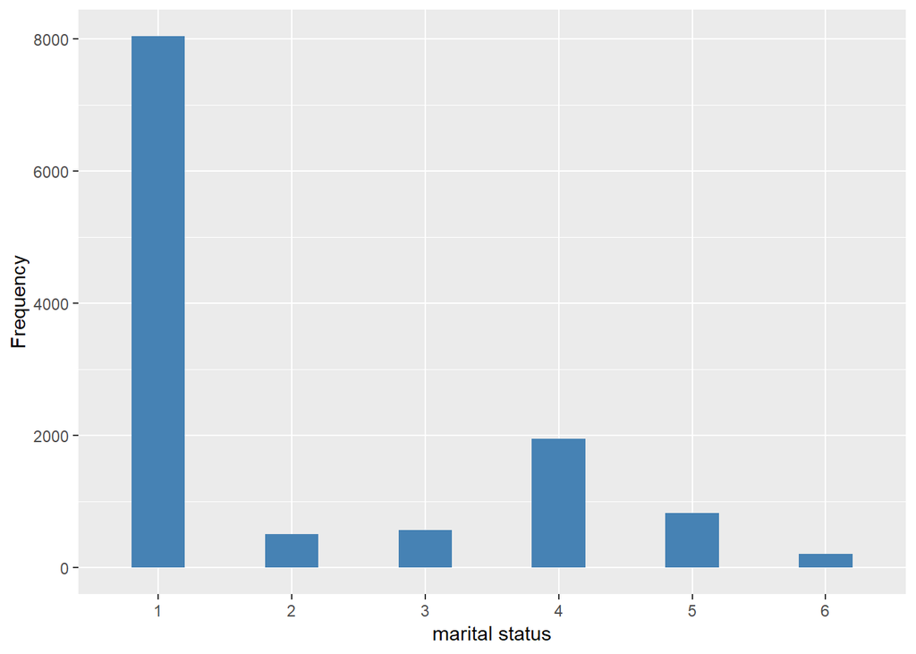

#### 2.1.1.2 Harmonisation algorithm

To compute the harmonize variable from the study-specific variable it has to be recoded as follows:

- `4 into 1`
- `1,2,3,5,6 into 0`
- `NA into 999`

**R script:**

```r
ELSA_ds_w1 <- tibble(id = ELSA_w1_bereav$id)
ELSA_ds_w1$bereav <- car::recode(as.vector(ELSA_w1_bereav$marstat), "4='1'; 1:3='0'; 5:6='0'; NA='999'")
ELSA_ds_w1$bereav <- labelled(ELSA_ds_w1$bereav, labels = c(No = 0, Yes = 1,
    Missing = 999, `Do not know` = 998, Refuse = 997, `Not applicable` = 996,
    `Don't answer` = 995, `Not attempt/not done/not yet recorded` = 994, `Disable to measure` = 993,
    Impute = 992, `CAPI/interviewer error` = 991))
```

#### 2.1.1.3 Statistical description of the new harmonised variable

| Sample size | Missing values |
| --- | --- |
| 12099 | 0 |

Category

|  | 0 | 1 |
| --- | --- | --- |
| Frequency | 10148.00 | 1951.00 |
| Percentage | 83.87 | 16.13 |

Type of missing

|  | 991 | 992 | 993 | 994 | 995 | 996 | 997 | 998 | 999 | NA |
| --- | --- | --- | --- | --- | --- | --- | --- | --- | --- | --- |
| Frequency | 0 | 0 | 0 | 0 | 0 | 0 | 0 | 0 | 0 | 0 |
| Percentage | 0 | 0 | 0 | 0 | 0 | 0 | 0 | 0 | 0 | 0 |

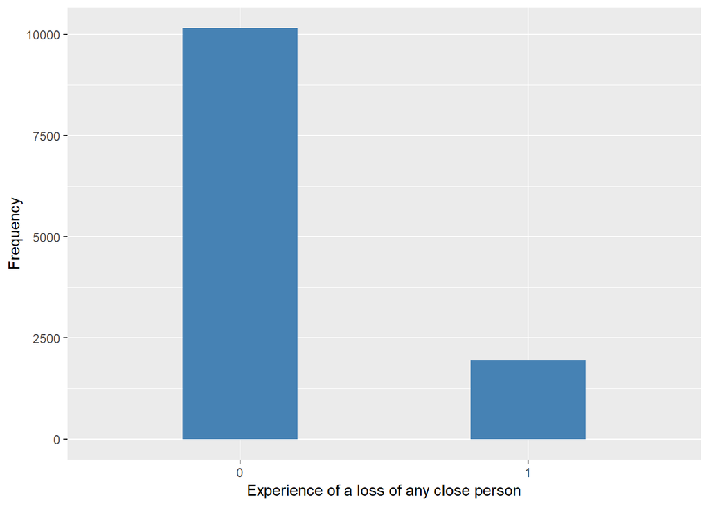

#### 2.1.1.4 Validation

|  | 1:3&5:6->0 | 4->1 |
| --- | --- | --- |
| BeforeH1 | 10148 | 1951 |
| AfterH | 10148 | 1951 |

### 2.1.2 Wave 2

#### 2.1.2.1 Study-specific variable description

| **Name** | `marstat` |
| --- | --- |
| **Label** | `marital status - couple1 combined with dimar` |
| **Table name** | `wave_2_ifs_derived_variables` |
| **Categories** | `1.0 = married (inc civ pship 06 onwards)` `2.0 = cohabiting` `3.0 = single, never married` `4.0 = widowed` `5.0 = divorced` `6.0 = separated` |
| **Description** |  |

MARSTAT

| Sample size | Missing values |
| --- | --- |
| 9432 | 0 |

Category

|  | 1 | 2 | 3 | 4 | 5 | 6 |
| --- | --- | --- | --- | --- | --- | --- |
| Frequency | 6185.00 | 407.00 | 418.00 | 1614.00 | 661.00 | 147.00 |
| Percentage | 65.57 | 4.32 | 4.43 | 17.11 | 7.01 | 1.56 |

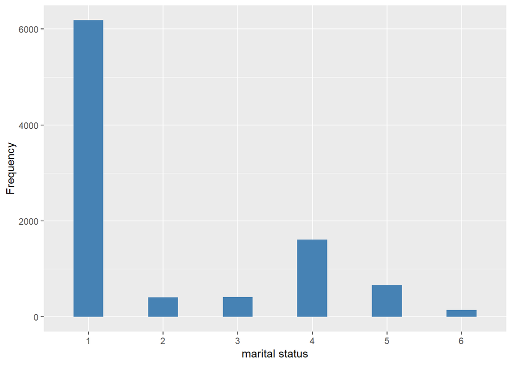

#### 2.1.2.2 Harmonisation algorithm

To compute the harmonize variable from the study-specific variable it has to be recoded as follows:

- `4 into 1`
- `1,2,3,5,6 into 0`
- `NA into 999`

**R script:**

```r
ELSA_ds_w2 <- tibble(id = ELSA_w2_bereav$id)
ELSA_ds_w2$bereav <- car::recode(as.vector(ELSA_w2_bereav$marstat), "4='1'; 1:3='0'; 5:6='0'; NA='999'")
ELSA_ds_w2$bereav <- labelled(ELSA_ds_w2$bereav, labels = c(No = 0, Yes = 1,
    Missing = 999, `Do not know` = 998, Refuse = 997, `Not applicable` = 996,
    `Don't answer` = 995, `Not attempt/not done/not yet recorded` = 994, `Disable to measure` = 993,
    Impute = 992, `CAPI/interviewer error` = 991))
```

#### 2.1.2.3 Statistical description of the new harmonised variable

| Sample size | Missing values |
| --- | --- |
| 9432 | 0 |

Category

|  | 0 | 1 |
| --- | --- | --- |
| Frequency | 7818.00 | 1614.00 |
| Percentage | 82.89 | 17.11 |

Type of missing

|  | 991 | 992 | 993 | 994 | 995 | 996 | 997 | 998 | 999 | NA |
| --- | --- | --- | --- | --- | --- | --- | --- | --- | --- | --- |
| Frequency | 0 | 0 | 0 | 0 | 0 | 0 | 0 | 0 | 0 | 0 |
| Percentage | 0 | 0 | 0 | 0 | 0 | 0 | 0 | 0 | 0 | 0 |

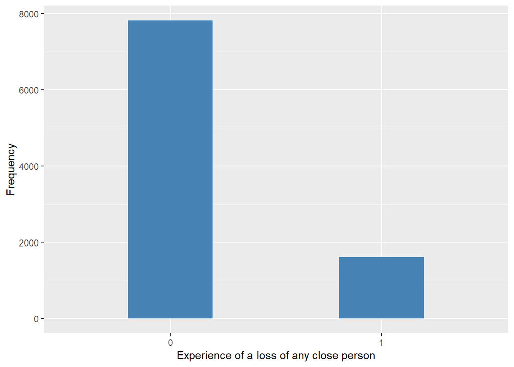

#### 2.1.2.4 Validation

|  | 1:3&5:6->0 | 4->1 |
| --- | --- | --- |
| BeforeH1 | 7818 | 1614 |
| AfterH | 7818 | 1614 |

### 2.1.3 Wave 3

#### 2.1.3.1 Study-specific variable description

| **Name** | `rsloswr` | `rsriskf` |
| --- | --- | --- |
| **Label** | `Ever lost a very close friend/relative in war or military service` | `Had v close friend/relative at risk of death/died due to illness/serious accid` |
| **Table name** | `wave_3_life_history_data` | `wave_3_life_history_data` |
| **Categories** | `1 = Yes` `2 = No` | `1 = Yes` `2 = No` |
| **Missings** | `-9 = Refusal` `-8 = Don't know` `-7 = Self completion not completed` `-2 = Respondent missed question` `-1 = Item not applicable` | `-9 = Refusal` `-8 = Don't know` `-7 = Self completion not completed` `-2 = Respondent missed question` `-1 = Item not applicable` |
| **Description** |  |  |

| Sample size | Missing values |
| --- | --- |
| 7833 | 1361 |

Category

|  | 1 | 2 |
| --- | --- | --- |
| Frequency | 741.00 | 5731.00 |
| Percentage | 9.46 | 73.16 |

Type of missing

|  | -9 | -8 | -7 | -2 | -1 | NA |
| --- | --- | --- | --- | --- | --- | --- |
| Frequency | 0 | 0 | 1267.00 | 94.0 | 0 | 0 |
| Percentage | 0 | 0 | 16.18 | 1.2 | 0 | 0 |

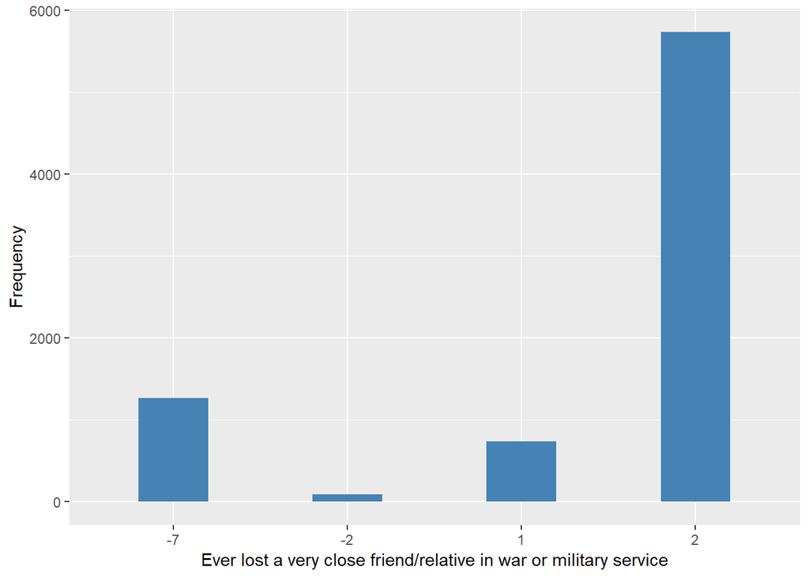

| Sample size | Missing values |
| --- | --- |
| 7833 | 1422 |

Category

|  | 1 | 2 |
| --- | --- | --- |
| Frequency | 4072.00 | 2339.00 |
| Percentage | 51.99 | 29.86 |

Type of missing

|  | -9 | -8 | -7 | -2 | -1 | NA |
| --- | --- | --- | --- | --- | --- | --- |
| Frequency | 0 | 0 | 1267.00 | 155.00 | 0 | 0 |
| Percentage | 0 | 0 | 16.18 | 1.98 | 0 | 0 |

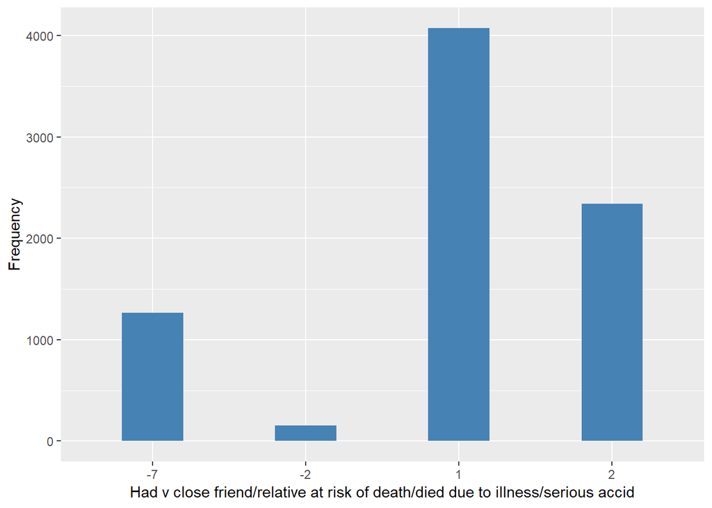

#### 2.1.3.2 Harmonisation algorithm

To recode the harmonize variable from the study-specific variable it has to be recoded as follows:

- `rsloswr=2 AND rsriskf=2 into 0`
- `rsloswr=1 OR rsriskf=1 into 1`
- `NA into 999`

**R script:**

```r
ELSA_ds_w3 <- tibble(id = ELSA_w3_bereav$id)

ELSA_w3_bereav$rsloswr <- car::recode(as.vector(ELSA_w3_bereav$rsloswr), "NA='-999'")
ELSA_w3_bereav$rsriskf <- car::recode(as.vector(ELSA_w3_bereav$rsriskf), "NA='-999'")

ELSA_ds_w3$bereav <- c(NA)
for (i in 1:dim(ELSA_w3_bereav)[1]) {
    if (ELSA_w3_bereav$rsloswr[i] == 1 | ELSA_w3_bereav$rsriskf[i] == 1) {
        ELSA_ds_w3$bereav[i] = 1
    } else if (ELSA_w3_bereav$rsloswr[i] == 2 & ELSA_w3_bereav$rsriskf[i] == 2) {
        ELSA_ds_w3$bereav[i] = 0
    } else if (ELSA_w3_bereav$rsloswr[i] == 2 & ELSA_w3_bereav$rsriskf[i] %in%
        c(-9, -8, -7, -2, -1)) {
        ELSA_ds_w3$bereav[i] <- car::recode(as.vector(ELSA_w3_bereav$rsriskf[i]),
            "-9='997'; -8='998'; -7='994'; -2='999'; -1='996'")
    } else if (ELSA_w3_bereav$rsloswr[i] %in% c(-9, -8, -7, -2, -1) & ELSA_w3_bereav$rsriskf[i] ==
        2) {
        ELSA_ds_w3$bereav[i] <- car::recode(as.vector(ELSA_w3_bereav$rsloswr[i]),
            "-9='997'; -8='998'; -7='994'; -2='999'; -1='996'")
    } else if (ELSA_w3_bereav$rsloswr[i] %in% c(-9, -8, -7, -2, -1) & ELSA_w3_bereav$rsloswr[i] ==
        ELSA_w3_bereav$rsriskf[i]) {
        ELSA_ds_w3$bereav[i] <- car::recode(as.vector(ELSA_w3_bereav$rsloswr[i]),
            "-9='997'; -8='998'; -7='994'; -2='999'; -1='996'")
    }
}

ELSA_ds_w3$bereav <- car::recode(as.vector(ELSA_ds_w3$bereav), "NA='999'")
ELSA_ds_w3$bereav <- labelled(ELSA_ds_w3$bereav, labels = c(No = 0, Yes = 1,
    Missing = 999, `Do not know` = 998, Refuse = 997, `Not applicable` = 996,
    `Don't answer` = 995, `Not attempt/not done/not yet recorded` = 994, `Disable to measure` = 993,
    Impute = 992, `CAPI/interviewer error` = 991))
```

#### 2.1.3.3 Statistical description of the new harmonised variable

| Sample size | Missing values |
| --- | --- |
| 7833 | 1422 |

Category

|  | 0 | 1 |
| --- | --- | --- |
| Frequency | 2084.00 | 4327.00 |
| Percentage | 26.61 | 55.24 |

Type of missing

|  | 991 | 992 | 993 | 994 | 995 | 996 | 997 | 998 | 999 | NA |
| --- | --- | --- | --- | --- | --- | --- | --- | --- | --- | --- |
| Frequency | 0 | 0 | 0 | 1267.00 | 0 | 0 | 0 | 0 | 155.00 | 0 |
| Percentage | 0 | 0 | 0 | 16.18 | 0 | 0 | 0 | 0 | 1.98 | 0 |

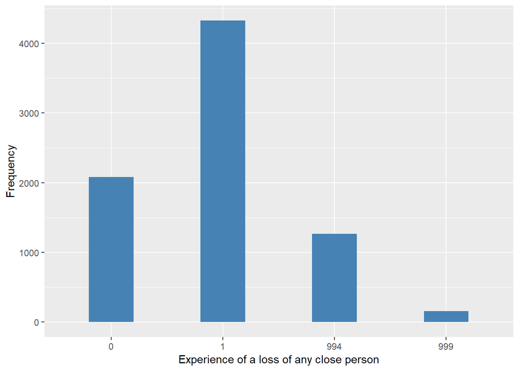

### 2.1.4 Wave 4

#### 2.1.4.1 Study-specific variable description

| **Name** | `marstat` |
| --- | --- |
| **Label** | `marital status - couple1 combined with dimar` |
| **Table name** | `wave_4_ifs_derived_variables` |
| **Categories** | `1.0 = married (inc civ pship 06 onwards)` `2.0 = cohabiting` `3.0 = single, never married` `4.0 = widowed` `5.0 = divorced` `6.0 = separated` |
| **Description** |  |

MARSTAT

| Sample size | Missing values |
| --- | --- |
| 11050 | 0 |

Category

|  | 1 | 2 | 3 | 4 | 5 | 6 |
| --- | --- | --- | --- | --- | --- | --- |
| Frequency | 7410.00 | 556.00 | 549.00 | 1538.00 | 861.00 | 136.00 |
| Percentage | 67.06 | 5.03 | 4.97 | 13.92 | 7.79 | 1.23 |

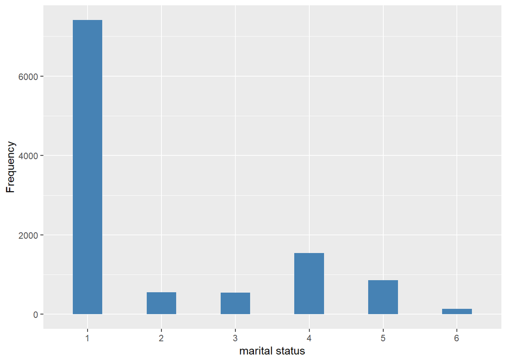

#### 2.1.4.2 Harmonisation algorithm

To recode the harmonize variable from the study-specific variable it has to be recoded as follows:

- `4 into 1`
- `1,2,3,5,6 into 0`
- `NA into 999`

**R script:**

```r
ELSA_ds_w4 <- tibble(id = ELSA_w4_bereav$id)
ELSA_ds_w4$bereav <- car::recode(as.vector(ELSA_w4_bereav$marstat), "4='1'; 1:3='0'; 5:6='0'; NA='999'")
ELSA_ds_w4$bereav <- labelled(ELSA_ds_w4$bereav, labels = c(No = 0, Yes = 1,
    Missing = 999, `Do not know` = 998, Refuse = 997, `Not applicable` = 996,
    `Don't answer` = 995, `Not attempt/not done/not yet recorded` = 994, `Disable to measure` = 993,
    Impute = 992, `CAPI/interviewer error` = 991))
```

#### 2.1.4.3 Statistical description of the new harmonised variable

| Sample size | Missing values |
| --- | --- |
| 11050 | 0 |

Category

|  | 0 | 1 |
| --- | --- | --- |
| Frequency | 9512.00 | 1538.00 |
| Percentage | 86.08 | 13.92 |

Type of missing

|  | 991 | 992 | 993 | 994 | 995 | 996 | 997 | 998 | 999 | NA |
| --- | --- | --- | --- | --- | --- | --- | --- | --- | --- | --- |
| Frequency | 0 | 0 | 0 | 0 | 0 | 0 | 0 | 0 | 0 | 0 |
| Percentage | 0 | 0 | 0 | 0 | 0 | 0 | 0 | 0 | 0 | 0 |

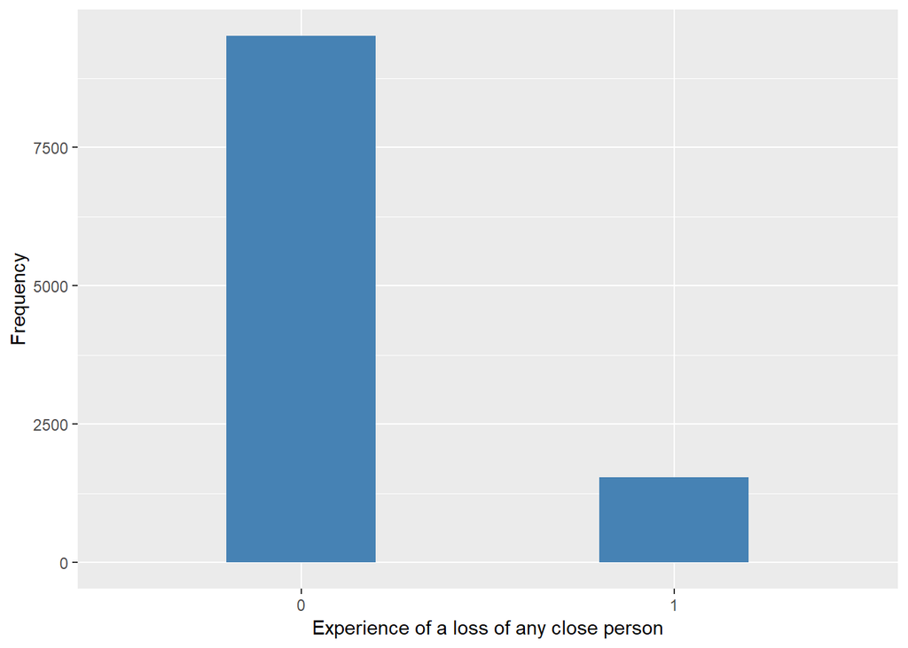

##### 2.1.4.3.1 Validation

|  | 1:3&5:6->0 | 4->1 |
| --- | --- | --- |
| BeforeH1 | 9512 | 1538 |
| AfterH | 9512 | 1538 |

### 2.1.5 Wave 5

#### 2.1.5.1 Study-specific variable description

| **Name** | `marstat` |
| --- | --- |
| **Label** | `marital status - couple1 combined with dimar` |
| **Table name** | `wave_5_ifs_derived_variables` |
| **Categories** | `1.0 = married (inc civ pship 06 onwards)` `2.0 = cohabiting` `3.0 = single, never married` `4.0 = widowed` `5.0 = divorced` `6.0 = separated` |
| **Description** |  |

MARSTAT

| Sample size | Missing values |
| --- | --- |
| 10274 | 0 |

Category

|  | 1 | 2 | 3 | 4 | 5 | 6 |
| --- | --- | --- | --- | --- | --- | --- |
| Frequency | 6818.00 | 533.00 | 470.00 | 1520.00 | 819.00 | 114.00 |
| Percentage | 66.36 | 5.19 | 4.57 | 14.79 | 7.97 | 1.11 |

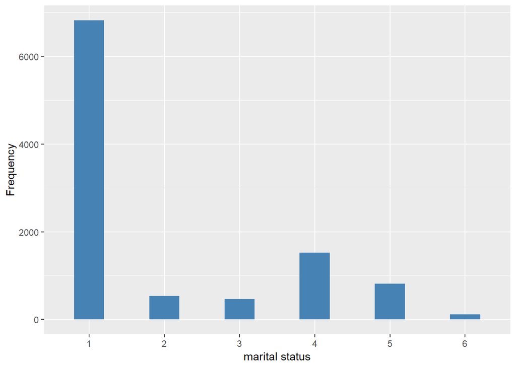

#### 2.1.5.2 Harmonisation algorithm

To recode the harmonize variable from the study-specific variable it has to be recoded as follows:

- `4 into 1`
- `1,2,3,5,6 into 0`
- `NA into 999`

**R script:**

```r
ELSA_ds_w5 <- tibble(id = ELSA_w5_bereav$id)
ELSA_ds_w5$bereav <- car::recode(as.vector(ELSA_w5_bereav$marstat), "4='1'; 1:3='0'; 5:6='0'; NA='999'")
ELSA_ds_w5$bereav <- labelled(ELSA_ds_w5$bereav, labels = c(No = 0, Yes = 1,
    Missing = 999, `Do not know` = 998, Refuse = 997, `Not applicable` = 996,
    `Don't answer` = 995, `Not attempt/not done/not yet recorded` = 994, `Disable to measure` = 993,
    Impute = 992, `CAPI/interviewer error` = 991))
```

#### 2.1.5.3 Statistical description of the new harmonised variable

| Sample size | Missing values |
| --- | --- |
| 10274 | 0 |

Category

|  | 0 | 1 |
| --- | --- | --- |
| Frequency | 8754.00 | 1520.00 |
| Percentage | 85.21 | 14.79 |

Type of missing

|  | 991 | 992 | 993 | 994 | 995 | 996 | 997 | 998 | 999 | NA |
| --- | --- | --- | --- | --- | --- | --- | --- | --- | --- | --- |
| Frequency | 0 | 0 | 0 | 0 | 0 | 0 | 0 | 0 | 0 | 0 |
| Percentage | 0 | 0 | 0 | 0 | 0 | 0 | 0 | 0 | 0 | 0 |

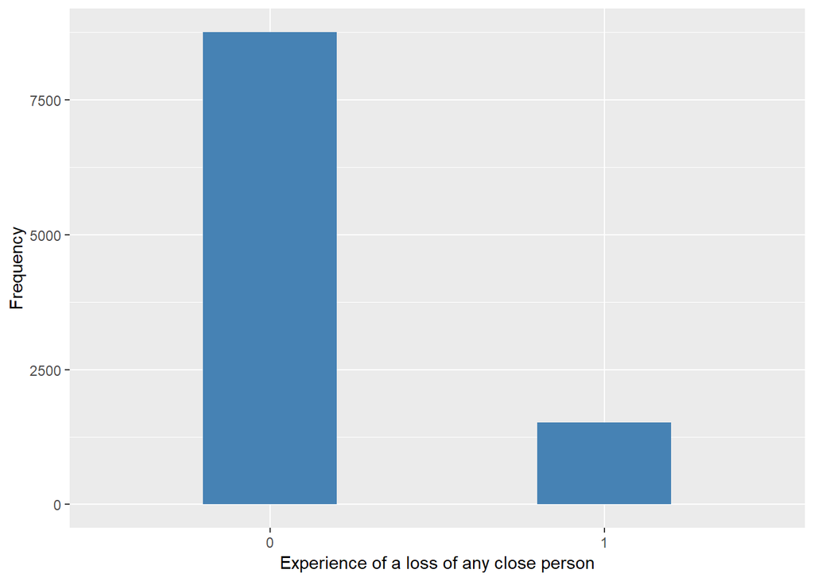

##### 2.1.5.3.1 Validation

|  | 1:3&5:6->0 | 4->1 |
| --- | --- | --- |
| BeforeH1 | 8754 | 1520 |
| AfterH | 8754 | 1520 |

### 2.1.6 Wave 6

#### 2.1.6.1 Study-specific variable description

| **Name** | `marstat` |
| --- | --- |
| **Label** | `marital status - couple1 combined with dimar` |
| **Table name** | `wave_6_ifs_derived_variables` |
| **Categories** | `1.0 = married (inc civ pship 06 onwards)` `2.0 = cohabiting` `3.0 = single, never married` `4.0 = widowed` `5.0 = divorced` `6.0 = separated` |
| **Description** |  |

MARSTAT

| Sample size | Missing values |
| --- | --- |
| 10601 | 0 |

Category

|  | 1 | 2 | 3 | 4 | 5 | 6 |
| --- | --- | --- | --- | --- | --- | --- |
| Frequency | 7015.00 | 615.0 | 515.00 | 1480.00 | 847.00 | 129.00 |
| Percentage | 66.17 | 5.8 | 4.86 | 13.96 | 7.99 | 1.22 |

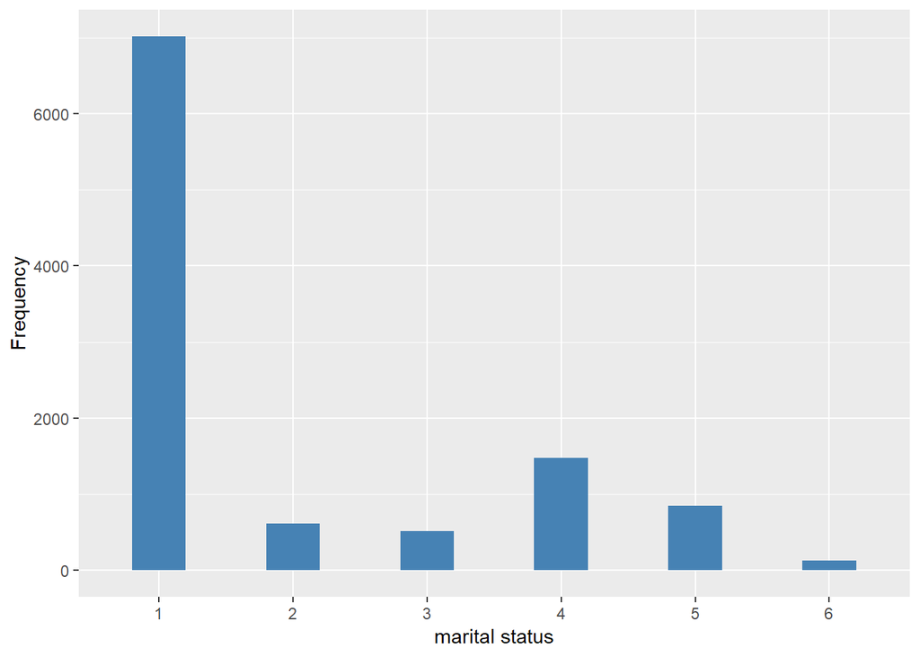

#### 2.1.6.2 Harmonisation algorithm

To recode the harmonize variable from the study-specific variable it has to be recoded as follows:

- `4 into 1`
- `1,2,3,5,6 into 0`
- `NA into 999`

**R script:**

```r
ELSA_ds_w6 <- tibble(id = ELSA_w6_bereav$id)
ELSA_ds_w6$bereav <- car::recode(as.vector(ELSA_w6_bereav$marstat), "4='1'; 1:3='0'; 5:6='0'; NA='999'")
ELSA_ds_w6$bereav <- labelled(ELSA_ds_w6$bereav, labels = c(No = 0, Yes = 1,
    Missing = 999, `Do not know` = 998, Refuse = 997, `Not applicable` = 996,
    `Don't answer` = 995, `Not attempt/not done/not yet recorded` = 994, `Disable to measure` = 993,
    Impute = 992, `CAPI/interviewer error` = 991))
```

#### 2.1.6.3 Statistical description of the new harmonised variable

| Sample size | Missing values |
| --- | --- |
| 10601 | 0 |

Category

|  | 0 | 1 |
| --- | --- | --- |
| Frequency | 9121.00 | 1480.00 |
| Percentage | 86.04 | 13.96 |

Type of missing

|  | 991 | 992 | 993 | 994 | 995 | 996 | 997 | 998 | 999 | NA |
| --- | --- | --- | --- | --- | --- | --- | --- | --- | --- | --- |
| Frequency | 0 | 0 | 0 | 0 | 0 | 0 | 0 | 0 | 0 | 0 |
| Percentage | 0 | 0 | 0 | 0 | 0 | 0 | 0 | 0 | 0 | 0 |

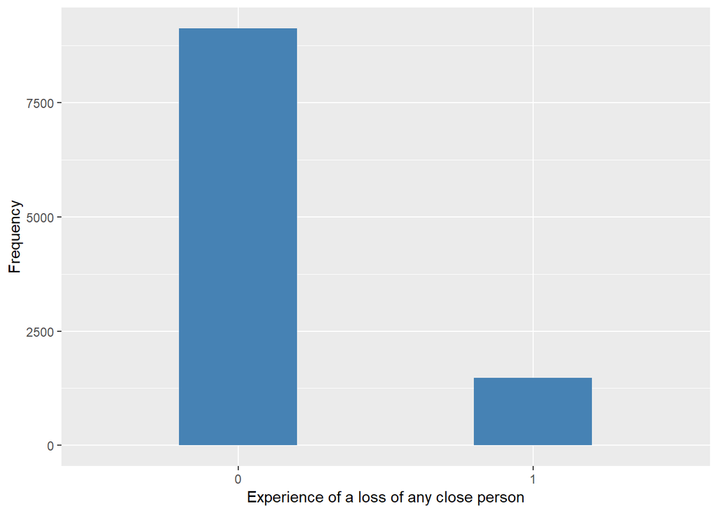

#### 2.1.6.4 Validation

|  | 1:3&5:6->0 | 4->1 |
| --- | --- | --- |
| BeforeH1 | 9121 | 1480 |
| AfterH | 9121 | 1480 |

### 2.1.7 Wave 7

#### 2.1.7.1 Study-specific variable description

| **Name** | `marstat` |
| --- | --- |
| **Label** | `marital status - couple1 combined with dimar` |
| **Table name** | `wave7_dv` |
| **Categories** | `1.0 = married (inc civ pship 06 onwards)` `2.0 = cohabiting` `3.0 = single, never married` `4.0 = widowed` `5.0 = divorced` `6.0 = separated` |
| **Description** |  |

| Sample size | Missing values |
| --- | --- |
| 9666 | 0 |

Category

|  | 1 | 2 | 3 | 4 | 5 | 6 |
| --- | --- | --- | --- | --- | --- | --- |
| Frequency | 6366.00 | 601.00 | 455.00 | 1341.00 | 779.00 | 124.00 |
| Percentage | 65.86 | 6.22 | 4.71 | 13.87 | 8.06 | 1.28 |

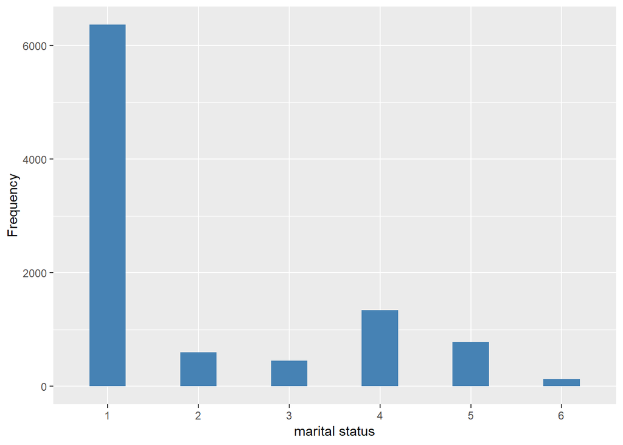

#### 2.1.7.2 Harmonisation algorithm

To recode the harmonize variable from the study-specific variable it has to be recoded as follows:

- `4 into 1`
- `1,2,3,5,6 into 0`
- `NA into 999`

#### 2.1.7.3 Statistics of the new harmonised variable

| Sample size | Missing values |
| --- | --- |
| 9666 | 0 |

Category

|  | 0 | 1 |
| --- | --- | --- |
| Frequency | 8325.00 | 1341.00 |
| Percentage | 86.13 | 13.87 |

Type of missing

|  | 991 | 992 | 993 | 994 | 995 | 996 | 997 | 998 | 999 | NA |
| --- | --- | --- | --- | --- | --- | --- | --- | --- | --- | --- |
| Frequency | 0 | 0 | 0 | 0 | 0 | 0 | 0 | 0 | 0 | 0 |
| Percentage | 0 | 0 | 0 | 0 | 0 | 0 | 0 | 0 | 0 | 0 |

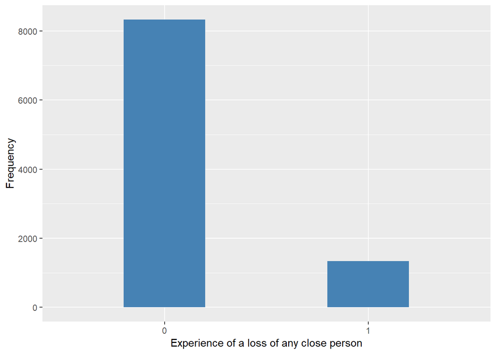

#### 2.1.7.4 Validation

|  | 1:3&5:6->0 | 4->1 |
| --- | --- | --- |
| BeforeH1 | 8325 | 1341 |
| AfterH | 8325 | 1341 |

## 2.2 Summary of descriptive statistics of the harmonised variable accross populations and waves

Two tables are generated:

1. Percentages of categories in each harmonised variable.
2. Frequencies and percentages of individuals with different trajectories. To avoid too large table, Only trajectories with percentages larger than 0.3 are shown.

Experience of a loss of any close person

| val | label | W1 | W2 | W3 | W4 | W5 | W6 | W7 |
| --- | --- | --- | --- | --- | --- | --- | --- | --- |
| 0 | No | 83.87 | 82.89 | 26.61 | 86.08 | 85.21 | 86.04 | 86.13 |
| 1 | Yes | 16.13 | 17.11 | 55.24 | 13.92 | 14.79 | 13.96 | 13.87 |
| 991 | CAPI interviewer error | 0 | 0 | 0 | 0 | 0 | 0 | 0 |
| 992 | Impute | 0 | 0 | 0 | 0 | 0 | 0 | 0 |
| 993 | Disable to measure | 0 | 0 | 0 | 0 | 0 | 0 | 0 |
| 994 | Not attempt not done | 0 | 0 | 16.18 | 0 | 0 | 0 | 0 |
| 995 | Does not answer | 0 | 0 | 0 | 0 | 0 | 0 | 0 |
| 996 | Not applicable | 0 | 0 | 0 | 0 | 0 | 0 | 0 |
| 997 | Refuse | 0 | 0 | 0 | 0 | 0 | 0 | 0 |
| 998 | Do not know | 0 | 0 | 0 | 0 | 0 | 0 | 0 |
| 999 | Missing | 0 | 0 | 1.98 | 0 | 0 | 0 | 0 |
| NA | NA | 0 | 0 | 0 | 0 | 0 | 0 | 0 |
| n | sample size | 12099 | 9432 | 7833 | 11050 | 10274 | 10601 | 9666 |

|  | val | frq | raw.prc |
| --- | --- | --- | --- |
| 1 | 0000000 | 838 | 4.58 |
| 3 | 000000NA | 127 | 0.69 |
| 9 | 00000NANA | 90 | 0.49 |
| 21 | 0000NANANA | 112 | 0.61 |
| 41 | 000NANANANA | 99 | 0.54 |
| 42 | 0010000 | 1880 | 10.27 |
| 44 | 001000NA | 196 | 1.07 |
| 50 | 00100NANA | 154 | 0.84 |
| 63 | 0010NANANA | 167 | 0.91 |
| 69 | 0011111 | 56 | 0.31 |
| 87 | 001NANANANA | 172 | 0.94 |
| 88 | 00NA0000 | 794 | 4.34 |
| 90 | 00NA000NA | 163 | 0.89 |
| 96 | 00NA00NANA | 110 | 0.60 |
| 109 | 00NA0NANANA | 178 | 0.97 |
| 123 | 00NANA000 | 80 | 0.44 |
| 130 | 00NANA0NANA | 62 | 0.34 |
| 143 | 00NANANANANA | 1454 | 7.95 |
| 209 | 0NANA0000 | 86 | 0.47 |
| 234 | 0NANANA000 | 56 | 0.31 |
| 252 | 0NANANANANANA | 1720 | 9.40 |
| 280 | 1101111 | 109 | 0.60 |
| 301 | 1111111 | 251 | 1.37 |
| 302 | 111111NA | 64 | 0.35 |
| 323 | 11NA1111 | 100 | 0.55 |
| 330 | 11NA1NANANA | 63 | 0.34 |
| 339 | 11NANANANANA | 380 | 2.08 |
| 356 | 1NANANANANANA | 453 | 2.48 |
| 380 | NANA00000 | 175 | 0.96 |
| 396 | NANA10000 | 399 | 2.18 |
| 421 | NANANA0000 | 1795 | 9.81 |
| 423 | NANANA000NA | 285 | 1.56 |
| 427 | NANANA00NA0 | 55 | 0.30 |
| 429 | NANANA00NANA | 200 | 1.09 |
| 436 | NANANA0NA00 | 62 | 0.34 |
| 443 | NANANA0NANANA | 406 | 2.22 |
| 450 | NANANA1111 | 109 | 0.60 |
| 458 | NANANANA000 | 113 | 0.62 |
| 466 | NANANANANA00 | 942 | 5.15 |
| 468 | NANANANANA0NA | 265 | 1.45 |
| 472 | NANANANANANA0 | 506 | 2.77 |

# 3 Quality estimation